# Methods: Tissue-specific transcriptional patterns underlie seasonal phenotypes in honey bees (*Apis mellifera*)

Sean Bresnahan, Mehmet Döke, Tugrul Giray and Christina Grozinger

Department of Entomology, Center for Pollinator Research, Huck Institutes of the Life Sciences, Pennsylvania State University  
Molecular, Cellular, and Integrative Biosciences Graduate Program, Huck Institutes of the Life Sciences, Pennsylvania State University  
Department of Biology, University of Puerto Rico, San Juan

stb5321@psu.edu

21 September 2021

GitHub repository for analysis code: https://github.com/sbresnahan/Winter-Honeybee-Transcriptome

```r
# Load packages
library(Biostrings)
library(tximport)
library(plyr)
library(kableExtra)
library(xtable)
library(ggplot2)
library(viridis)
library(DESeq2)
library(ggdendro)
library(grid)
library(rrcov)
library(topGO)
library(GO.db)
suppressWarnings(library(ViSEAGO))
library(factoextra)
```

# 1 Abstract

Faced with adverse conditions, such as winter in temperate regions or hot and dry conditions in tropical regions, many insect species enter a state of diapause, a period of dormancy associated with a reduction or arrest of physical activity, development, and reproduction. Changes in common physiological pathways underlie diapause phenotypes in different insect species. However, most transcriptomic studies of diapause have not simultaneously evaluated and compared expression patterns in different tissues. Honey bees (*Apis mellifera*) represent a unique model system to study the mechanisms underpinning diapause-related phenotypes. In winter, honey bees exhibit a classic diapause phenotype, with reduced metabolic activity, increased physiological nutritional resources, and altered hormonal profiles. However, winter bees actively heat their colony by vibrating their wing muscles; thus, this tissue is not quiescent. Here, we evaluated the transcriptional profiles of flight muscle tissue and fat body tissue (involved in nutrient storage, metabolism and immune function) of winter bees. We also evaluated two behavioral phenotypes of summer bees: nurses, which exhibit high nutritional stores and low flight activity, and foragers, which exhibit low nutritional stores and high flight activity. We found winter bees and nurses have similar fat body transcriptional profiles, whereas winter bees and foragers have similar flight muscle transcriptional profiles. Additionally, differentially expressed genes were enriched in diapause-related GO terms. Thus, honey bees exhibit tissue-specific transcriptional profiles associated with seasonal phenotypes, laying the groundwork for future studies evaluating the mechanisms, evolution, and consequences of this tissue-specific regulation.

# 2 RNA-seq data analysis

## 2.1 Download reference genome

We first obtained the RefSeq *Apis mellifera* [Amel_HAv3.1 genome assembly](https://ftp.ncbi.nih.gov/genomes/refseq/invertebrate/Apis_mellifera/annotation_releases/104/GCF_003254395.2_Amel_HAv3.1/) and the NCBI Annotation Report v104 (AR104) GFF file from NCBI.

```bash
DIR_INDEX="data/index"
cd ${DIR_INDEX}

wget -O Amel_HAv3.1.fna.gz https://ftp.ncbi.nlm.nih.gov/genomes/all/GCF/003/254/395/GCF_003254395.2_Amel_HAv3.1/GCF_003254395.2_Amel_HAv3.1_genomic.fna.gz
gunzip Amel_HAv3.1.fna.gz
wget -O Amel_HAv3.1.gff.gz https://ftp.ncbi.nlm.nih.gov/genomes/all/GCF/003/254/395/GCF_003254395.2_Amel_HAv3.1/GCF_003254395.2_Amel_HAv3.1_genomic.gff.gz
gunzip Amel_HAv3.1.gff.gz
```

## 2.2 Retrieve RNA-seq reads

RNA libraries were prepared by the Sequencing and Genomic Technologies Shared Resource at the Duke Center for Genomic and Computational Biology, Durham, NC, and sequenced on an Illumina HiSeq 4000 platform. Transcriptomic data generated from this study were deposited in the NCBI Short Read Archive (SRA) database (BioProject accession [PRJNA601517](https://www.ncbi.nlm.nih.gov/bioproject/?term=prjna601517)).

```bash
DIR_SRA="data/raw"

cd ${DIR_SRA}

SRA=("SRR10901308" "SRR10901307" "SRR10901296" "SRR10901291" "SRR10901290" \
     "SRR10901289" "SRR10901288" "SRR10901287" "SRR10901286" "SRR10901285" \
     "SRR10901306" "SRR10901305" "SRR10901304" "SRR10901303" "SRR10901302" \
     "SRR10901301" "SRR10901300" "SRR10901299" "SRR10901298" "SRR10901297" \
     "SRR10901295" "SRR10901294" "SRR10901293" "SRR10901292")

for i in "${SRA[@]}"
do
  prefetch -O ${DIR_SRA} ${i}
  fasterq-dump -O ${DIR_SRA} ${DIR_SRA}/${i}.sra
  rm sra/{i}.sra
done
```

## 2.3 RNA-seq read pre-processing (TrimGalore!: cutadapt & FastQC)

RNA-seq reads were assessed for quality control metrics after adapter trimming with Trim Galore (Krueger, 2019) - a wrapper tool around Cutadapt (Martin, 2011) and FastQC (Andrews, n.d.).

```bash
DIR_TRIM="data/trimmed"

for i in "${SRA[@]}"
do
  trim_galore --fastqc -j 8 --paired -o ${DIR_TRIM} ${i}_1.fastq ${i}_2.fastq
done
```

## 2.4 Pseudo-alignment and transcript abundance estimates (Kallisto)

We then used Kallisto (Bray et al., 2016) to quantify transcript abundance by pseudo-alignment on the latest release of the *Apis mellifera* genome assembly Amel_HAv3.1 (Wallberg et al., 2019).

```bash
cd ${DIR_INDEX}

gffread Amel_HAv3.1.gff -g Amel_HAv3.1.fna -w Amel_HAv3.1_transcripts.fasta -F

kallisto index --make-unique -i kallisto_Amel_HAv3.1 Amel_HAv3.1_transcripts.fasta

cd ${DIR_TRIM}

DIR_KALLISTO="data/kallisto"

for i in "${SRA[@]}"
do
  kallisto quant -i ${DIR_INDEX}/kallisto_Amel_HAv3.1 -o ${DIR_KALLISTO}/${i} \
   -t 2 ${i}_1_val_1.fq ${i}_2_val_2.fq
done
```

## 2.5 Generate gene expression matrix from kallisto transcript abundance estimates (tximport)

We then compiled the transcript abundance estimates for each sample into an expression matrix in R (Team, 2019), and summed by gene using the tximport method (Soneson et al., 2020).

### 2.5.1 Make tx2gene database

```bash
cd ${DIR_INDEX}

grep -v '^#' Amel_HAv3.1.gtf | awk '$3=="exon";$3=="CDS" { print $0 }' | \
   sed 's/.*GeneID://' | awk -F'"' '{print $1}' > transcript_GeneIDs.txt

grep -v '^#' Amel_HAv3.1.gtf | awk '$3=="exon";$3=="CDS" { print $0 }' | \
   sed 's/.*transcript_id \"//' | awk -F'"' '{print $1}' > transcript_IDs.txt

paste -d'\t' transcript_IDs.txt transcript_GeneIDs.txt | \
   awk -v OFS="," '{print "rna-"$1, $2}' | sort | uniq > tx2gene.csv
```

```r
tx2gene <- read.csv("data/index/tx2gene.csv",header=F)
names(tx2gene) <- c("tx_id","gene_id")
write.csv(tx2gene,"data/index/tx2gene.csv")
```

### 2.5.2 tximport kallisto abundance.tsv files

```r
tx2gene <- read.csv("data/index/tx2gene.csv",header=T)
dirs.kallisto <- list.dirs("data/kallisto", recursive=FALSE)
files.list <- list()
for (i in 1:length(dirs.kallisto)){
  files.list[i] <- paste(unlist(dirs.kallisto[i]),"abundance.tsv",sep="/")
}
txi <- tximport(unlist(files.list), type = "kallisto",
                    tx2gene = tx2gene,geneIdCol="gene_id",txIdCol="tx_id")
datExpr <- as.data.frame(txi[["counts"]])
dirnames.l <- length(unlist(strsplit(unlist(dirs.kallisto),"/")[1]))
dirnames <- sapply(strsplit(unlist(dirs.kallisto),"/"), "[", dirnames.l)
names(datExpr) <- dirnames
CDS_geneIDs <- unique(read.table("data/index/CDS_geneIDs.txt")[,c(1)])
datExpr <- datExpr[row.names(datExpr)%in%CDS_geneIDs,]
write.csv(datExpr,"data/res/counts.csv")
write.csv(datExpr,"Manuscript/tabs4.csv")
## Clear all
rm(list=ls())
```

### 2.5.3 Load sample metadata

```r
metadata <- read.csv("data/index/metadata.csv")
metadata$Label <- rep.int(c("W1","W2","W3","W4",
                            "F1","F2","F3","F4",
                            "N1","N2","N3","N4"),2)
metadata <- data.frame(lapply(metadata, factor))
datExpr <- read.csv("data/res/counts.csv")
row.names(datExpr) <- datExpr$X
datExpr$X <- NULL
datExpr <- datExpr[,as.character(metadata$Accession)]
```

Through RNA-sequencing we obtained an average transcript abundance of ~13.8 million pseudo-alignments for each biological replicate of nurse, forager, and winter honey bees.

```r
tabs3 <- data.frame(Estimate=colSums(datExpr))
tabs3 <- data.frame(Accession=row.names(tabs3),Estimate=tabs3$Estimate)
tabs3 <- plyr::join(tabs3,metadata,by="Accession")
tabs3 <- tabs3[,c(1,4,3,6,2)]
tabs3 <- tabs3[order(tabs3$Tissue,tabs3$Label),]
tabs3$Tissue <- revalue(tabs3$Tissue, c("A"="Fat body", "T"="Flight muscle"))
mean(tabs3$Estimate)
```

```
## [1] 13779637
```

```r
tabs3 %>%
  kbl(label="Table S3", caption = "RNAseq library metadata and pseudoalignment rates on the Amel_HAv3.1 kallisto reference transcriptome",
      row.names=F) %>% kable_classic(full_width = F)
```

(#tab:Table S3)RNAseq library metadata and pseudoalignment rates on the Amel_HAv3.1 kallisto reference transcriptome

| Accession | Tissue | Group | Label | Estimate |
| --- | --- | --- | --- | --- |
| SRR10901290 | Fat body | F | F1 | 10395684 |
| SRR10901289 | Fat body | F | F2 | 10622663 |
| SRR10901288 | Fat body | F | F3 | 9812492 |
| SRR10901287 | Fat body | F | F4 | 9819590 |
| SRR10901286 | Fat body | N | N1 | 10183143 |
| SRR10901285 | Fat body | N | N2 | 54816483 |
| SRR10901306 | Fat body | N | N3 | 13566677 |
| SRR10901305 | Fat body | N | N4 | 10478171 |
| SRR10901308 | Fat body | W | W1 | 7589701 |
| SRR10901307 | Fat body | W | W2 | 9205696 |
| SRR10901296 | Fat body | W | W3 | 7878113 |
| SRR10901291 | Fat body | W | W4 | 10567136 |
| SRR10901300 | Flight muscle | F | F1 | 10403286 |
| SRR10901299 | Flight muscle | F | F2 | 9635344 |
| SRR10901298 | Flight muscle | F | F3 | 11763683 |
| SRR10901297 | Flight muscle | F | F4 | 8376154 |
| SRR10901295 | Flight muscle | N | N1 | 10773543 |
| SRR10901294 | Flight muscle | N | N2 | 10828715 |
| SRR10901293 | Flight muscle | N | N3 | 13273847 |
| SRR10901292 | Flight muscle | N | N4 | 10450605 |
| SRR10901304 | Flight muscle | W | W1 | 8936265 |
| SRR10901303 | Flight muscle | W | W2 | 51554954 |
| SRR10901302 | Flight muscle | W | W3 | 9490797 |
| SRR10901301 | Flight muscle | W | W4 | 10288543 |

```r
write.csv(tabs3,"Manuscript/tabs3.csv")
```

Low count genes (< 1 count across > 25% of samples) and genes with 0% variance across all samples were removed from the analysis.

```r
datExpr <- datExpr[rowMeans(datExpr!=0)>0.25, ]
datExpr <- round(datExpr)
```

This resulted in 92.4% (9,178/9,935) of the *A. mellifera* protein coding genes (Wallberg et al., 2019) being represented in this study.

```r
head(datExpr[c(1:5),c(1:5)]) %>%
  kbl(caption = "Preview of the count matrix: first 5 genes and samples") %>%
  kable_classic(full_width = F)
```

Table 1: Preview of the count matrix: first 5 genes and samples

|  | SRR10901308 | SRR10901307 | SRR10901296 | SRR10901291 | SRR10901290 |
| --- | --- | --- | --- | --- | --- |
| 100037419 | 0 | 9 | 11 | 42 | 33 |
| 100049551 | 0 | 40 | 31 | 0 | 7 |
| 100126690 | 46 | 0 | 28 | 38 | 21 |
| 100174948 | 12 | 12 | 4 | 8 | 7 |
| 100187709 | 43 | 51 | 54 | 3 | 36 |

# 3 Differential gene expression analysis

We used DESeq2 (Love et al., 2014) to assess differential expression of protein-coding genes (DEGs) within tissue types between nurse, forager, and winter bees, using colony as a co-factor. In each analysis, we applied the default Benjamini-Hochberg (Benjamini & Hochberg, 1995) correction and set the threshold for differential expression at $padj<0.05$. Gene ontology enrichment analyses were performed using topGO (Alexa et al., 2006) using Flybase orthologs. To assess sample relationships and variance, hierarchical clustering analysis was conducted on the variance stabilized transformed counts generated by DESeq2.

```r
plot.hclust <- function(data,sample.info,title,tissue=c("A","T")){
  sample.info <- sample.info[sample.info$Tissue==tissue,]
  names(data) <- sample.info$Label

  data.plot <- cor(data)
  data.dendro <- hclust(dist(data.plot))
  data.dendro <- dendro_data(data.dendro)
  label.order <- data.dendro[["labels"]][["label"]]

  p1.plot <- ggplot() + geom_segment(data = segment(data.dendro),
                               aes_string(x = "x", y = "y",
                                          xend = "xend", yend = "yend")) +
    geom_text(data = label(data.dendro),
              aes_string(x = "x", y = "y", label = "label"),
              hjust = 0.5, vjust = 1.5, angle = 0, size=6) +
    scale_y_continuous(expand=c(0.2, 0)) +
    xlab("") + ylab("") +
    theme_void()

  p2.plot <- ggplot() + geom_segment(data = segment(data.dendro),
                               aes_string(x = "x", y = "y",
                                          xend = "xend", yend = "yend")) +
    geom_text(data = label(data.dendro),
              aes_string(x = "x", y = "y", label = "label"),
              hjust = -0.5, vjust = 0.5, angle = 0, size=6) +
    xlab("") + ylab("") +
    theme_void() + coord_flip() + scale_y_reverse(expand=c(0.4,0))

  data.plot <- as.matrix(dist(t(data)))
  data.plot <- data.plot[label.order,label.order]
  data.plot[lower.tri(data.plot)] <- NA
  data.plot <- reshape2::melt(data.plot)

  data.plot$Var1 <- factor(data.plot$Var1,
                           levels = label.order)
  data.plot$Var2 <- factor(data.plot$Var2,
                           levels = label.order)

  g.plot <- ggplot(data = data.plot, aes(x = Var1, y = Var2)) +
  geom_tile(aes(fill = value)) +
  scale_fill_viridis(direction=-1, na.value="white") +
    xlab("") + ylab("") +
    theme_void() + guides(fill=F)

  grid.newpage()
  print(g.plot,
        vp = viewport(x = 0.65, y = 0.35, width = 0.7, height = 0.7))
  print(p1.plot,
        vp = viewport(x = 0.65, y = 0.85, width = 0.7, height = 0.3))
  print(p2.plot,
        vp = viewport(x = .155, y = 0.35, width = 0.3, height = 0.7))
}

create.hclustPlot <- function(...){
  plot_heatmap <- function() plot.hclust(...)
}
```

## 3.1 DESeq: Fat body

```r
datExpr.A <- as.matrix(datExpr[names(datExpr)%in%metadata[metadata$Tissue=="A","Accession"]])
dds.A <- DESeqDataSetFromMatrix(countData=datExpr.A,
                                colData=metadata[metadata$Tissue=="A",],
                                design=~Colony+Group)
DESeq.A <- DESeq(dds.A)
dds.A.transform <- data.frame(assay(varianceStabilizingTransformation(DESeq.A, blind=F)))
```

## 3.2 DESeq: Flight muscle

```r
datExpr.T <- as.matrix(datExpr[names(datExpr)%in%metadata[metadata$Tissue=="T","Accession"]])
dds.T <- DESeqDataSetFromMatrix(countData=datExpr.T,
                                colData=metadata[metadata$Tissue=="T",],
                                design=~Colony+Group)
DESeq.T <- DESeq(dds.T)
dds.T.transform <- data.frame(assay(varianceStabilizingTransformation(DESeq.T, blind=F)))
```

## 3.3 Figure S1

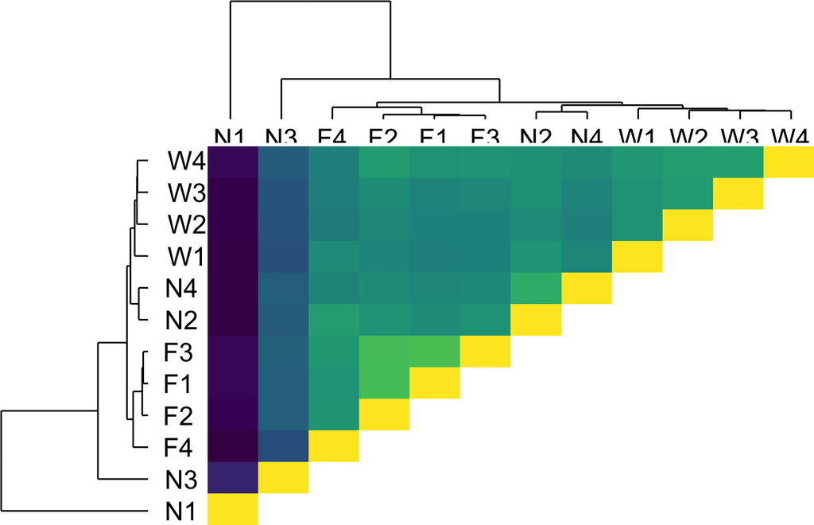

```r
plot.hclust.A <- create.hclustPlot(dds.A.transform, metadata,
                             '',tissue="A")
plot.hclust.A()
```

```r
ggsave(file="Manuscript/figs1.pdf", plot=plot.hclust.A(), width=10, height=8)
```

**Figure S1**: Fat body tissue sample relationships between nurse, forager, and winter bees as determined by pairwise correlations and hierarchical clustering. Sample relationships determined using all tested genes (*n* = 9,178).

## 3.4 Figure S2

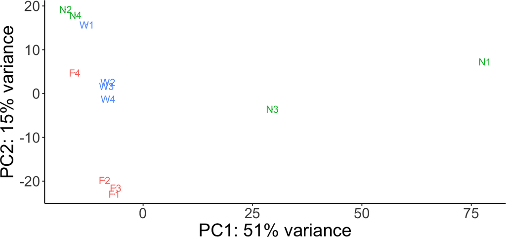

**Figure S2**: Fat body tissue sample relationships between nurse, forager, and winter bees as determined by principal component analysis (PCA). Sample relationships determined using all tested genes (*n* = 9,178).

## 3.5 Outlier detection

```r
checkpca <- PcaGrid(t(dds.A.transform))
outliers <- which(checkpca@flag=='FALSE')
print(paste("Outlier:",names(outliers),sep=" "))
```

```
## [1] "Outlier: SRR10901286"
```

```r
# Remove the offending accessions
datExpr <- datExpr[,!names(datExpr)%in%names(outliers)]
metadata <- metadata[!metadata$Accession%in%names(outliers),]
```

```r
datExpr.A <- as.matrix(datExpr[names(datExpr)%in%metadata[metadata$Tissue=="A","Accession"]])
dds.A <- DESeqDataSetFromMatrix(countData=datExpr.A,
                                colData=metadata[metadata$Tissue=="A",],
                                design=~Colony+Group)
DESeq.A <- DESeq(dds.A)
dds.A.transform <- data.frame(assay(varianceStabilizingTransformation(DESeq.A, blind=F)))
```

```r
checkpca <- PcaGrid(t(dds.A.transform))
outliers <- which(checkpca@flag=='FALSE')
print(paste("Outlier:",names(outliers),sep=" "))
```

```
## [1] "Outlier: SRR10901306"
```

```r
# Remove the offending accessions
datExpr <- datExpr[,!names(datExpr)%in%names(outliers)]
metadata <- metadata[!metadata$Accession%in%names(outliers),]
```

```r
datExpr.A <- as.matrix(datExpr[names(datExpr)%in%metadata[metadata$Tissue=="A","Accession"]])
dds.A <- DESeqDataSetFromMatrix(countData=datExpr.A,
                                colData=metadata[metadata$Tissue=="A",],
                                design=~Colony+Group)
DESeq.A <- DESeq(dds.A)
dds.A.transform <- data.frame(assay(varianceStabilizingTransformation(DESeq.A, blind=F)))
```

## 3.6 Figure 1

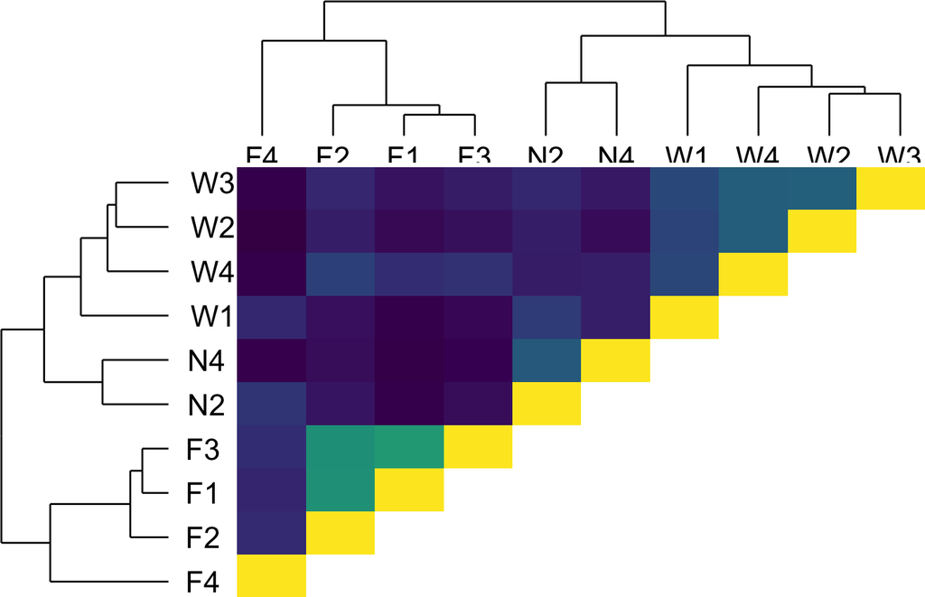

```r
plot.hclust.A <- create.hclustPlot(dds.A.transform, metadata,
                             '',tissue="A")
plot.hclust.A()
```

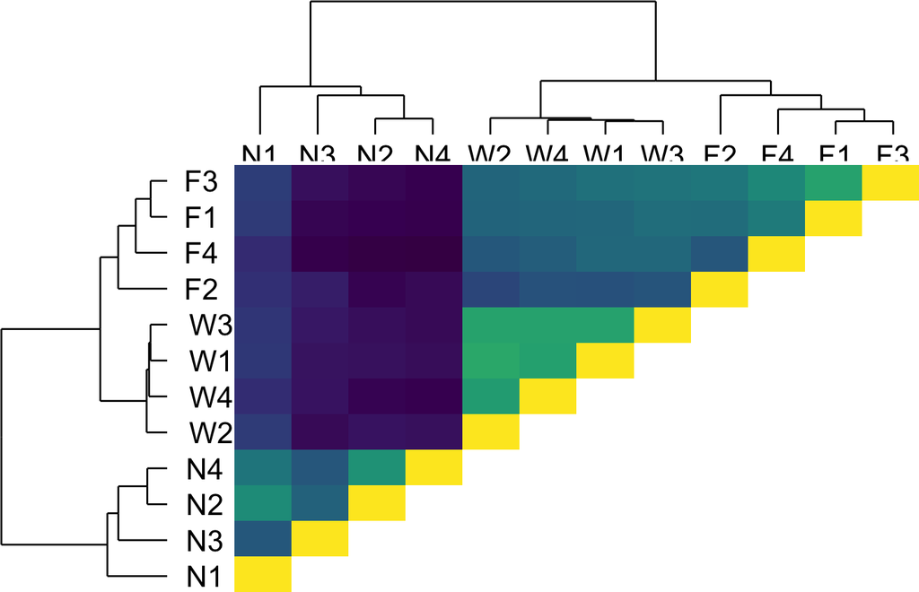

```r
ggsave(file="Manuscript/fig1a.pdf", plot=plot.hclust.A(), width=10, height=8)

plot.hclust.T <- create.hclustPlot(dds.T.transform, metadata,
                             '',tissue="T")
plot.hclust.T()
```

```r
ggsave(file="Manuscript/fig1b.pdf", plot=plot.hclust.T(), width=10, height=8)
```

**Figure 1**: **Clustering analysis demonstrates transcriptional correlations between winter bees and nurse bees in fat body tissue (a) and winter bees and foragers in flight muscle tissue (b)**. The relationships among the samples were determined by pairwise correlations and hierarchical clustering, using all tested genes (*n* = 9,178).

```r
# CUSTOM FUNCTION: Generate lists of up- and down-regulated DEGs and optionally save csv
cond.contrast <- function(object,contVar,group1,group2,padj.threshold,
                          LFC.threshold=0,save.results=T,results.filename){
  # Create a data.frame for the results of the DESeq object given a contrast
  res <- data.frame(results(object, contrast=c(contVar,group1,group2)))
  # Order by padj
  res <- res[order(res$padj),]
  # Filter by padj.threshold
  DEGs <- res[res$padj<padj.threshold,]
  # Remove empty rows
  DEGs <- na.omit(DEGs)
  # Get list of upregulated genes, considering log2fc or not
  if(LFC.threshold==0){up <- row.names(DEGs[DEGs$log2FoldChange>0,])}else{
    up <- row.names(DEGs[DEGs$log2FoldChange>LFC.threshold,])
  }
  # Get list of downregulated genes, considering log2fc or not
  if(LFC.threshold==0){down <- row.names(DEGs[DEGs$log2FoldChange<0,])}else{
    down <- row.names(DEGs[DEGs$log2FoldChange<-LFC.threshold,])
  }
  # Optionally, save csv
  if(save.results==T){write.csv(DEGs,results.filename)}
  return(list(up,down,res))
}
```

## 3.7 Tables S3-S8

```r
NvF.A <- cond.contrast(DESeq.A,"Group","N","F",
                       padj.threshold=0.05,
                       save.results=F,
                       results.filename="Manuscript/tabs3.csv")

WvF.A <- cond.contrast(DESeq.A,"Group","W","F",
                       padj.threshold=0.05,
                       save.results=F,
                       results.filename="Manuscript/tabs4.csv")

WvN.A <- cond.contrast(DESeq.A,"Group","W","N",
                       padj.threshold=0.05,
                       save.results=F,
                       results.filename="Manuscript/tabs5.csv")
```

```r
# Call cond.contrast for each contrast
NvF.T <- cond.contrast(DESeq.T,"Group","N","F",
                       padj.threshold=0.05,
                       save.results=F,
                       results.filename="Manuscript/tabs6.csv")

WvF.T <- cond.contrast(DESeq.T,"Group","W","F",
                       padj.threshold=0.05,
                       save.results=F,
                       results.filename="Manuscript/tabs7.csv")

WvN.T <- cond.contrast(DESeq.T,"Group","W","N",
                       padj.threshold=0.05,
                       save.results=F,
                       results.filename="Manuscript/tabs8.csv")
```

## 3.8 Table 1

```r
DEGs <- data.frame(Tissue=c(rep("Abdomen",3),rep("Thorax",3)),
                   Contrast=c("NvF","WvN","WvF","NvF","WvN","WvF"),
                   Upregulated=c(length(NvF.A[[1]]),length(WvN.A[[1]]),length(WvF.A[[1]]),
                                 length(NvF.T[[1]]),length(WvN.T[[1]]),length(WvF.T[[1]])),
                   Downregulated=c(length(NvF.A[[2]]),length(WvN.A[[2]]),length(WvF.A[[2]]),
                                 length(NvF.T[[2]]),length(WvN.T[[2]]),length(WvF.T[[2]])))
write.csv(DEGs,"Manuscript/tab1.csv")
```

```r
DEGs %>%
  kbl(label="Table 1", caption = "Summary of the differentially expressed protein coding genes across winter, nurse and forager bee samples. The total number of differentially expressed and number of up- versus down-regulated genes are provided.",
      row.names=F) %>% kable_classic(full_width = F)
```

(#tab:Table 1)Summary of the differentially expressed protein coding genes across winter, nurse and forager bee samples. The total number of differentially expressed and number of up- versus down-regulated genes are provided.

| Tissue | Contrast | Upregulated | Downregulated |
| --- | --- | --- | --- |
| Abdomen | NvF | 342 | 341 |
| Abdomen | WvN | 359 | 575 |
| Abdomen | WvF | 674 | 943 |
| Thorax | NvF | 1382 | 1381 |
| Thorax | WvN | 1443 | 1412 |
| Thorax | WvF | 540 | 636 |

# 4 Gene Ontology Enrichment Analysis (topGO)

Gene ontology (GO) enrichment analyses were performed with the “elim” method from topGO (Alexa et al., 2006), using *Drosophila melanogaster* orthologs of honey bee genes converted via a one-to-one reciprocal best hit BLAST (Table S15).

```r
dmel_go <- read.table("data/index/dmel_gene_association.fb",
                      sep="\t",header=1,
                      comment.char="!",
                      na.strings=".",
                      stringsAsFactors=FALSE,
                      quote="", fill=FALSE)[,c(1,2,3,5,7)]
names(dmel_go) <- c("taxid","gene_id","gene_symbol","GOID","evidence")
dmel_go$gene_symbol <- dmel_go$gene_id
dmel_go <- dmel_go[dmel_go$GOID%in%keys(GO.db),]
dmel_go <- dmel_go[!dmel_go$evidence=="ND",]
dmel_go <- dmel_go[complete.cases(dmel_go), ]
amel_to_dmel <- read.csv("data/index/amel_to_dmel.csv")
dmel_go <- dmel_go[dmel_go$gene_id%in%amel_to_dmel$dmel.gene,]
write.table(dmel_go,"data/index/dmel_custom.txt",
            sep="\t",quote=F,row.names=F)
Custom_GENE2GO <- ViSEAGO::Custom2GO("data/index/dmel_custom.txt")
Custom_GENE2GO <- ViSEAGO::annotate("FB",Custom_GENE2GO)
```

## 4.1 GOEA function

```r
GOEA <- function(DEG.object,contrast,tissue){
  geneList0 <- amel_to_dmel$dmel.gene
  myInterestingGenes <- c(unlist(DEG.object[1]),
                          unlist(DEG.object[2]))
  myInterestingGenes <- amel_to_dmel[amel_to_dmel$amel.gene%in%myInterestingGenes,2]
  geneList <- factor(as.integer(geneList0 %in% myInterestingGenes))
  names(geneList) <- geneList0
  GOdata <- new("topGOdata", ontology = "BP", allGenes = geneList,
                annot = annFUN.gene2GO, gene2GO = Custom_GENE2GO@BP)
  test <- runTest(GOdata, algorithm ="elim", statistic = "fisher")
  results <- GenTable(GOdata,elim=test,topNodes=length(test@score))
  results <- suppressWarnings(results[!is.na(as.numeric(as.character(results$elim))),])
  results <- suppressWarnings(results[!is.na(results$elim),])
  results$elim <- as.numeric(results$elim)
  results$percent.coverage <- results$Significant/results$Annotated
  results.sig <- results[results$elim<0.05,]
  rank <- list()
  for(i in 1:length(results.sig$GO.ID)){
    rank[i] <- length(unlist(as.list(GOBPCHILDREN[results.sig$GO.ID[i]])))
  }
  results.sig$rank <- unlist(rank)
  results.sig$contrast <- contrast
  results.sig$tissue <- tissue
  return(results.sig)
}
```

## 4.2 GOEA (Tables S9-S14)

```r
NvF.A.GO <- GOEA(NvF.A,"NvF","Fat body")
write.csv(NvF.A.GO[,c(1:5,7,6)],"Manuscript/tabs9.csv",row.names=F)
WvF.A.GO <- GOEA(WvF.A,"WvF","Fat body")
write.csv(WvF.A.GO[,c(1:5,7,6)],"Manuscript/tabs10.csv",row.names=F)
WvN.A.GO <- GOEA(WvN.A,"WvN","Fat body")
write.csv(WvN.A.GO[,c(1:5,7,6)],"Manuscript/tabs11.csv",row.names=F)

NvF.T.GO <- GOEA(NvF.T,"NvF","Flight muscle")
write.csv(NvF.T.GO[,c(1:5,7,6)],"Manuscript/tabs12.csv",row.names=F)
WvF.T.GO <- GOEA(WvF.T,"WvF","Flight muscle")
write.csv(WvF.T.GO[,c(1:5,7,6)],"Manuscript/tabs13.csv",row.names=F)
WvN.T.GO <- GOEA(WvN.T,"WvN","Flight muscle")
write.csv(WvN.T.GO[,c(1:5,7,6)],"Manuscript/tabs14.csv",row.names=F)
```

## 4.3 Tables 3 & 4

```r
percent <- function(x, digits = 2, format = "f", ...){
  paste0(formatC(x * 100, format = format, digits = digits, ...), "%")
}

tab3 <- rbind(NvF.A.GO,WvF.A.GO,WvN.A.GO,
              NvF.T.GO,WvF.T.GO,WvN.T.GO)
tab4 <- tab3[tab3$tissue=="Flight muscle",]
tab3 <- tab3[tab3$tissue=="Fat body",]
DEGs_A <- length(unique(c(NvF.A[[1]],NvF.A[[2]],
                   WvF.A[[1]],WvF.A[[2]],
                   WvN.A[[1]],WvN.A[[2]])))
DEGs_T <- length(unique(c(NvF.T[[1]],NvF.T[[2]],
                   WvF.T[[1]],WvF.T[[2]],
                   WvN.T[[1]],WvN.T[[2]])))

tab3 <- tab3[tab3$elim<0.01,]
tab3 <- tab3[tab3$Annotated<(DEGs_A*0.25),]
tab3 <- tab3[order(-tab3$Annotated),]
row.names(tab3) <- NULL
tab3 <- tab3[1:20,]
tab3$percent.coverage <- percent(tab3$percent.coverage)
tab3$Coverage <- paste(paste(tab3$Significant,
                             tab3$Annotated,sep="/"),
                       paste("(",tab3$percent.coverage,")",sep=""),sep=" ")
tab3 <- tab3[,c(9,1,2,11,6)]
names(tab3) <- c("Contrast","GO.ID","Term","Coverage","p")
tab3 <- tab3[order(tab3$Contrast),]
tab3$p <- formatC(tab3$p, format = "e", digits = 2)
tab3 %>%
  kbl(label="Table 3",
      caption = "Significantly enriched gene ontology terms identified in fat body DEGs", row.names=F) %>%
  kable_classic(full_width = F)
```

(#tab:Table 3)Significantly enriched gene ontology terms identified in fat body DEGs

| Contrast | GO.ID | Term | Coverage | p |
| --- | --- | --- | --- | --- |
| NvF | GO:0023057 | negative regulation of signaling | 31/308 (10.06%) | 7.50e-03 |
| NvF | GO:0010648 | negative regulation of cell communicatio… | 31/307 (10.10%) | 7.16e-03 |
| NvF | GO:0050877 | nervous system process | 36/306 (11.76%) | 2.40e-04 |
| NvF | GO:0097485 | neuron projection guidance | 25/227 (11.01%) | 5.17e-03 |
| NvF | GO:0022604 | regulation of cell morphogenesis | 21/131 (16.03%) | 4.62e-03 |
| NvF | GO:0007623 | circadian rhythm | 16/126 (12.70%) | 6.28e-03 |
| NvF | GO:0050804 | modulation of chemical synaptic transmis… | 17/120 (14.17%) | 1.53e-03 |
| WvF | GO:0007166 | cell surface receptor signaling pathway | 106/533 (19.89%) | 4.15e-03 |
| WvF | GO:0048666 | neuron development | 106/512 (20.70%) | 8.18e-03 |
| WvF | GO:0016310 | phosphorylation | 94/483 (19.46%) | 5.19e-03 |
| WvF | GO:0000904 | cell morphogenesis involved in different… | 87/395 (22.03%) | 4.84e-03 |
| WvF | GO:0050877 | nervous system process | 62/306 (20.26%) | 9.15e-03 |
| WvF | GO:0007163 | establishment or maintenance of cell pol… | 39/170 (22.94%) | 4.58e-03 |
| WvF | GO:0048813 | dendrite morphogenesis | 31/128 (24.22%) | 4.73e-03 |
| WvN | GO:0032879 | regulation of localization | 66/447 (14.77%) | 9.80e-04 |
| WvN | GO:0048569 | post-embryonic animal organ development | 51/386 (13.21%) | 2.40e-03 |
| WvN | GO:0009886 | post-embryonic animal morphogenesis | 49/385 (12.73%) | 6.13e-03 |
| WvN | GO:0010256 | endomembrane system organization | 26/156 (16.67%) | 4.45e-03 |
| WvN | GO:0048813 | dendrite morphogenesis | 21/128 (16.41%) | 4.27e-03 |
| WvN | GO:0009953 | dorsal/ventral pattern formation | 25/126 (19.84%) | 1.15e-03 |

```r
write.csv(tab3,"Manuscript/tab3.csv")
```

```r
tab4 <- tab4[tab4$elim<0.01,]
tab4 <- tab4[tab4$Annotated<(DEGs_A*0.25),]
tab4 <- tab4[order(-tab4$Annotated),]
row.names(tab4) <- NULL
tab4 <- tab4[1:20,]
tab4$percent.coverage <- percent(tab4$percent.coverage)
tab4$Coverage <- paste(paste(tab4$Significant,
                             tab4$Annotated,sep="/"),
                       paste("(",tab4$percent.coverage,")",sep=""),sep=" ")
tab4 <- tab4[,c(9,1,2,11,6)]
names(tab4) <- c("Contrast","GO.ID","Term","Coverage","p")
tab4 <- tab4[order(tab4$Contrast),]
tab4$p <- formatC(tab4$p, format = "e", digits = 2)
tab4 %>%
  kbl(label="Table 4",
      caption = "Significantly enriched gene ontology terms identified in flight muscle DEGs", row.names=F) %>%
  kable_classic(full_width = F)
```

(#tab:Table 4)Significantly enriched gene ontology terms identified in flight muscle DEGs

| Contrast | GO.ID | Term | Coverage | p |
| --- | --- | --- | --- | --- |
| NvF | GO:0007166 | cell surface receptor signaling pathway | 181/533 (33.96%) | 1.80e-03 |
| NvF | GO:0007292 | female gamete generation | 161/511 (31.51%) | 6.54e-03 |
| NvF | GO:0000904 | cell morphogenesis involved in different… | 128/395 (32.41%) | 5.36e-03 |
| NvF | GO:0006468 | protein phosphorylation | 124/364 (34.07%) | 8.20e-04 |
| NvF | GO:0009967 | positive regulation of signal transducti… | 113/342 (33.04%) | 4.40e-03 |
| NvF | GO:0009968 | negative regulation of signal transducti… | 98/284 (34.51%) | 1.79e-03 |
| WvF | GO:0048666 | neuron development | 81/512 (15.82%) | 8.70e-04 |
| WvF | GO:0045934 | negative regulation of nucleobase-contai… | 51/317 (16.09%) | 5.57e-03 |
| WvN | GO:0007166 | cell surface receptor signaling pathway | 193/533 (36.21%) | 3.88e-03 |
| WvN | GO:0048666 | neuron development | 181/512 (35.35%) | 7.04e-03 |
| WvN | GO:0007292 | female gamete generation | 180/511 (35.23%) | 4.89e-03 |
| WvN | GO:0009790 | embryo development | 145/429 (33.80%) | 2.27e-03 |
| WvN | GO:0048584 | positive regulation of response to stimu… | 150/422 (35.55%) | 1.54e-03 |
| WvN | GO:0003002 | regionalization | 135/387 (34.88%) | 9.49e-03 |
| WvN | GO:0032990 | cell part morphogenesis | 138/377 (36.60%) | 5.01e-03 |
| WvN | GO:0006468 | protein phosphorylation | 126/364 (34.62%) | 1.66e-03 |
| WvN | GO:0007560 | imaginal disc morphogenesis | 125/330 (37.88%) | 5.74e-03 |
| WvN | GO:0035220 | wing disc development | 124/329 (37.69%) | 8.66e-03 |
| WvN | GO:0016477 | cell migration | 99/259 (38.22%) | 1.41e-03 |
| WvN | GO:0001745 | compound eye morphogenesis | 92/259 (35.52%) | 2.92e-03 |

```r
write.csv(tab4,"Manuscript/tab4.csv")
```

# 5 K-means clustering

We performed k-means clustering Kassambara (2019) to specifically test whether the tissue-specific transcriptomes of winter bees had more in common with foragers or nurses, given *k* = 2 clusters (see Figure S4 for the variance explained by additional values of *k*). Separate tests were performed using: 1) all genes passing our initial low-count filter (*n* = 9,178), and 2) only forager vs nurse DEGs (Figure S5).

## 5.1 Subset gene expression by all DEGs

```r
A.gene.list.union <- unique(c(WvF.A[[2]],WvF.A[[1]],WvN.A[[2]],WvN.A[[1]]))
T.gene.list.union <- unique(c(WvF.T[[2]],WvF.T[[1]],WvN.T[[2]],WvN.T[[1]]))
gene.list.union <- unique(c(A.gene.list.union,T.gene.list.union))

A.union.dds.transform <- dds.A.transform[row.names(dds.A.transform)%in%A.gene.list.union,]
T.union.dds.transform <- dds.T.transform[row.names(dds.T.transform)%in%T.gene.list.union,]

tempA <- A.union.dds.transform[row.names(A.union.dds.transform)%in%gene.list.union,]
tempT <- T.union.dds.transform[row.names(T.union.dds.transform)%in%gene.list.union,]
tempA <- tempA[match(row.names(tempT), row.names(tempA)),]

union.dds.transform <- cbind(tempA,tempT)
```

## 5.2 Subset gene expression by forager vs. nurse DEGs

```r
FvN.A.gene.list.union <- intersect(unique(c(WvF.A[[2]],WvF.A[[1]],WvN.A[[2]],WvN.A[[1]])),
                                   unique(NvF.A[[2]],NvF.A[[1]]))
FvN.T.gene.list.union <- intersect(unique(c(WvF.T[[2]],WvF.T[[1]],WvN.T[[2]],WvN.T[[1]])),
                                   unique(NvF.T[[2]],NvF.T[[1]]))
FvN.gene.list.union <- unique(c(FvN.A.gene.list.union,FvN.T.gene.list.union))

FvN.A.union.dds.transform <- dds.A.transform[row.names(dds.A.transform)%in%FvN.A.gene.list.union,]
FvN.T.union.dds.transform <- dds.T.transform[row.names(dds.T.transform)%in%FvN.T.gene.list.union,]

tempA <- A.union.dds.transform[row.names(A.union.dds.transform)%in%FvN.gene.list.union,]
tempT <- T.union.dds.transform[row.names(T.union.dds.transform)%in%FvN.gene.list.union,]
tempA <- tempA[match(row.names(tempT), row.names(tempA)),]

FvN.union.dds.transform <- cbind(tempA,tempT)
```

## 5.3 Test optimal number of clusters

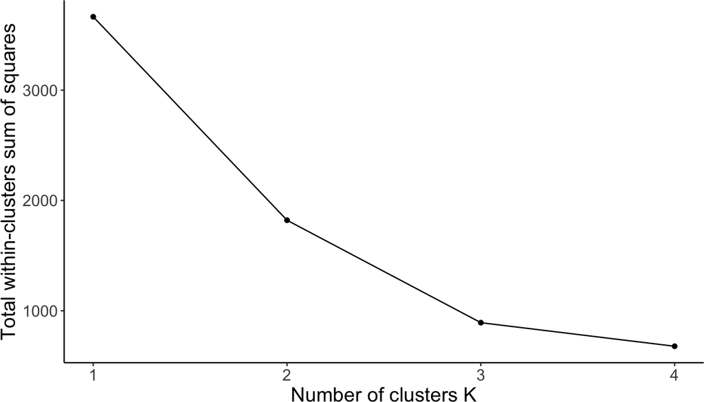

```r
km.data.A <- A.union.dds.transform[apply(A.union.dds.transform, 1, var) != 0,]
km.data.A <- t(km.data.A)

wss.A <- sapply(1:4,
              function(k){kmeans(km.data.A,
                                 k,
                                 nstart=50,
                                 iter.max = 15 )$tot.withinss})
wss.A.df <- data.frame(cluster=c(1:4),
                     WSS=wss.A)
wss.A.plot <- ggplot(data=wss.A.df, aes(x=cluster, y=WSS)) +
  geom_line() + geom_point() + theme_classic() +
  xlab("Number of clusters K") +
  ylab("Total within-clusters sum of squares") +
  scale_x_continuous(breaks=c(1,2,3,4)) +
  theme(text=element_text(size=16)) +
  ggtitle("")
wss.A.plot
```

```r
ggsave(file="Manuscript/figs4a.pdf", plot=wss.A.plot, width=5, height=5)
```

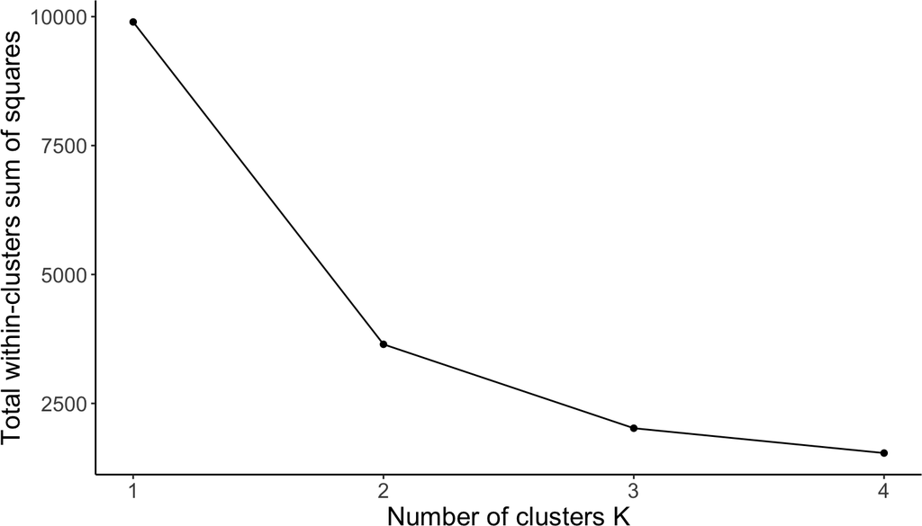

```r
km.data.T <- T.union.dds.transform[apply(T.union.dds.transform, 1, var) != 0,]
km.data.T <- t(km.data.T)

wss.T <- sapply(1:4,
              function(k){kmeans(km.data.T,
                                 k,
                                 nstart=50,
                                 iter.max = 15 )$tot.withinss})
wss.T.df <- data.frame(cluster=c(1:4),
                     WSS=wss.T)
wss.T.plot <- ggplot(data=wss.T.df, aes(x=cluster, y=WSS)) +
  geom_line() + geom_point() + theme_classic() +
  xlab("Number of clusters K") +
  ylab("Total within-clusters sum of squares") +
  scale_x_continuous(breaks=c(1,2,3,4)) +
  theme(text=element_text(size=16)) +
  ggtitle("")
wss.T.plot
```

```r
ggsave(file="Manuscript/figs4b.pdf", plot=wss.T.plot, width=5, height=5)
```

## 5.4 mod.fviz_cluster function

```r
mod.fviz_cluster <- function(data,sample.info,showLegend=T,K,lim=150)
{
  data <- data[apply(data, 1, var) != 0,]
  data <- t(data)
  object <- kmeans(data,K,iter.max=1000,nstart=2)

  f <- fviz_cluster(object, data = data, geom="text",
                    repel=T,show.clust.cent=F,ellipse=T,
                    ellipse.type="confidence",labelsize=10,
                    main="",
                    ggtheme=theme_classic(),
                    ellipse.level=.95) + theme(legend.position = "none")

  f.y <- sapply(strsplit(f[["labels"]][["y"]],"Dim2 "),"[", 2)
  f.y <- gsub("\\(", "", f.y)
  f.y <- gsub("\\)", "", f.y)
  f.y <- paste("PC2:",f.y,"variance",sep=" ")

  f.x <- sapply(strsplit(f[["labels"]][["x"]],"Dim1 "),"[", 2)
  f.x <- gsub("\\(", "", f.x)
  f.x <- gsub("\\)", "", f.x)
  f.x <- paste("PC1:",f.x,"variance",sep=" ")

  d <- data.frame(PC1 = f[["data"]]$x, PC2 = f[["data"]]$y,
                  group = sample.info$Group,
                  cluster = f[["data"]]$cluster)

  g <- ggplot(data = d, aes(x = PC1, y = PC2, color = cluster, shape = group)) +
    geom_point(size = 3) + xlab(f.x) + ylab(f.y)  + theme_classic() +
    stat_ellipse(type = "norm", linetype = 2, inherit.aes = F,
                 aes(x = PC1, y = PC2, color = cluster)) +
    stat_ellipse(type = "t", inherit.aes = F,
                 aes(x = PC1, y = PC2, color = cluster)) +
    theme(text = element_text(size=20),
          plot.margin = margin(1, 1, 1, 1, "cm"),
          legend.title=element_blank()) + guides(color=F) +
    xlim(-lim,lim) + ylim(-lim,lim) + scale_color_grey()

  if(showLegend==F){g <- g + theme(legend.position="none")}

  return(g)
}
```

## 5.5 Figure 2

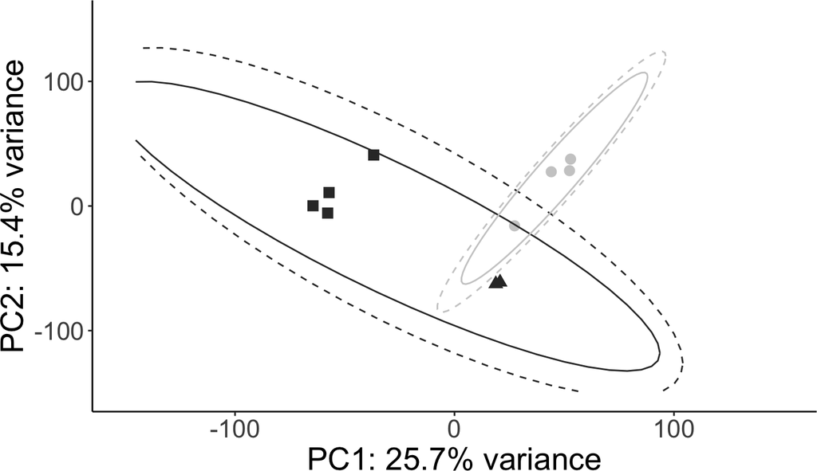

```r
# Abdomen
abdomen_kmeans.plot <- mod.fviz_cluster(dds.A.transform,
                                        metadata[metadata$Tissue=="A",],
                                        showLegend=F,K=2)
ggsave(file="Manuscript/fig2a.pdf", plot=abdomen_kmeans.plot,
       width=6, height=5)

abdomen_kmeans.plot
```

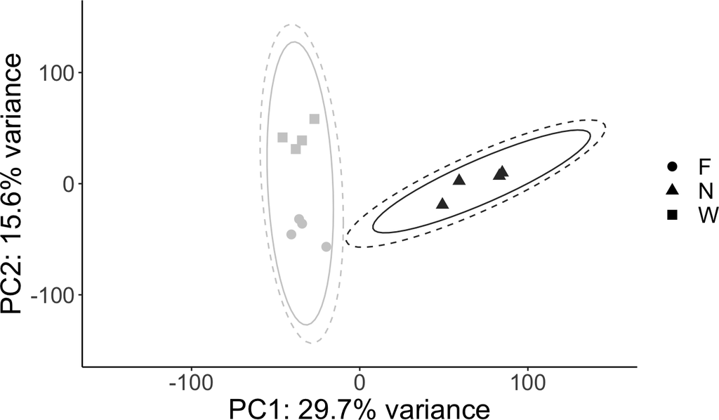

```r
# Thorax
thorax_kmeans.plot <- mod.fviz_cluster(dds.T.transform,
                                       metadata[metadata$Tissue=="T",],
                                       showLegend=T,K=2)
ggsave(file="Manuscript/fig2b.pdf", plot=thorax_kmeans.plot,
       width=6, height=5)

thorax_kmeans.plot
```

**Figure 2**: k-means clustering demonstrates **transcriptional similarities between winter bees and nurse bees in fat body tissue (a) and winter bees and foragers in flight muscle tissue (b)**. Dotted lines indicate 95% confidence intervals.

## 5.6 Figure S5

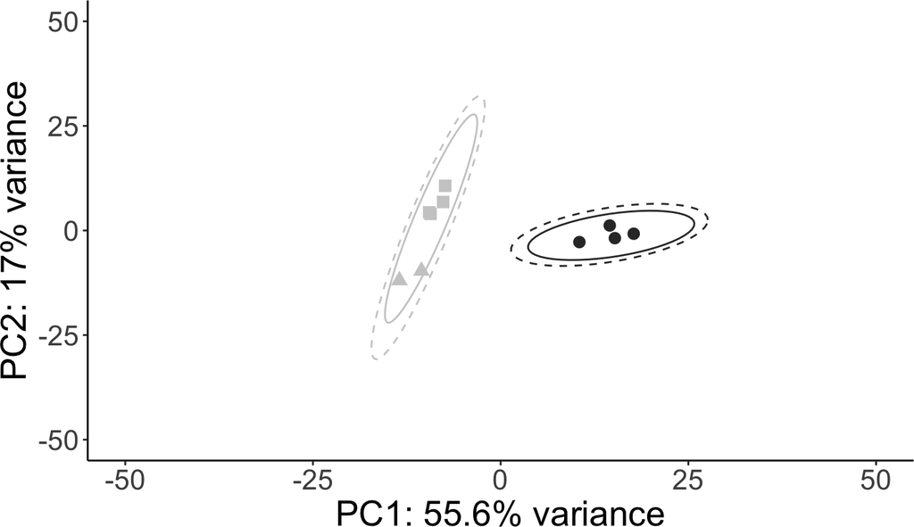

```r
# Abdomen
abdomen_kmeans.plot <- mod.fviz_cluster(FvN.A.union.dds.transform,
                                        metadata[metadata$Tissue=="A",],
                                        showLegend=F,K=2,
                                        lim=50)
abdomen_kmeans.plot
```

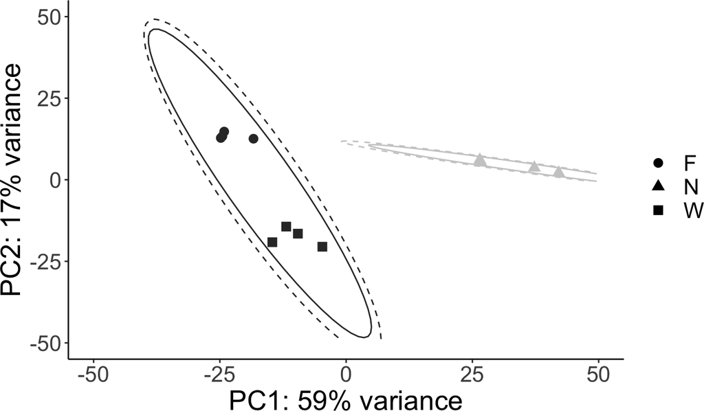

```r
ggsave(file="Manuscript/figs5a.pdf", plot=abdomen_kmeans.plot,
       width=6, height=5)

# Thorax
thorax_kmeans.plot <- mod.fviz_cluster(FvN.T.union.dds.transform,
                                       metadata[metadata$Tissue=="T",],
                                       showLegend=T,K=2,
                                       lim=50)
thorax_kmeans.plot
```

```r
ggsave(file="Manuscript/figs5b.pdf", plot=thorax_kmeans.plot,
       width=6, height=5)
```

**Figure S5**: k-means clustering of *a)* fat body and *b)* flight muscle tissue samples for FvN DEGs (*n* = 1,266). Dotted lines indicate 95% confidence intervals.

# 6 Chi-squared tests

We performed chi-squared tests to determine, for each tissue, whether the number of DEGs between winter bees and nurses is significantly different than the number of DEGs between winter bees and foragers.

```r
# Abdomen
chisq.table.A <- as.matrix(data.frame(Winter_DEG=c(length(WvN.A[[1]])+length(WvN.A[[2]]),
                                         length(WvF.A[[1]])+length(WvF.A[[2]])),
                            Winter_not_DEG=c(length(row.names(datExpr))-(length(WvN.A[[1]])+length(WvN.A[[2]])),
                                             length(row.names(datExpr))-(length(WvF.A[[1]])+length(WvF.A[[2]]))),
                            row.names=c("to_Nurse",
                                        "to_Forager")))
chisq.test.A <- chisq.test(x=chisq.table.A)
chisq.test.A
```

```
##
##  Pearson's Chi-squared test with Yates' continuity correction
##
## data:  chisq.table.A
## X-squared = 211.76, df = 1, p-value < 2.2e-16
```

```r
# Thorax
chisq.table.T <- as.matrix(data.frame(Winter_DEG=c(length(WvN.T[[1]])+length(WvN.T[[2]]),
                                         length(WvF.T[[1]])+length(WvF.T[[2]])),
                            Winter_not_DEG=c(length(row.names(datExpr))-(length(WvN.T[[1]])+length(WvN.T[[2]])),
                                             length(row.names(datExpr))-(length(WvF.T[[1]])+length(WvF.T[[2]]))),
                            row.names=c("to_Nurse",
                                        "to_Forager")))
chisq.test.T <- chisq.test(x=chisq.table.T)
chisq.test.T
```

```
##
##  Pearson's Chi-squared test with Yates' continuity correction
##
## data:  chisq.table.T
## X-squared = 895.06, df = 1, p-value < 2.2e-16
```

There are clearly more genes differentially expressed between winter bees and forager bees (versus nurse bees) in the fat body tissues ($\chi^{2}=211.76$, $p<2.26*10^{-16}$), suggesting that winter bees are more similar to nurse bees in this tissue. In the flight muscle, there are more genes differentially expressed between winter bees and nurse bees (relative to forager bees; $\chi^{2}=895.06$, $p<2.26*10^{-16}$), suggesting that winter bees are more similar to forager bees in this tissue.

# 7 GO Overlap

GO terms found to be associated with diapause in bumble bees (*Bombus terrestris*) (Amsalem et al., 2015), an oil-collecting bee *Tetrapedia diversipes* (Santos et al., 2018), alfalfa leaf-cutting bees (*Megachile rotundata*) (Yocum et al., 2018), and across 11 insect species spanning Diptera, Lepidoptera, and Hymenoptera (Ragland et al., 2019) were compiled from previous studies (Table S16). We then tested whether significantly enriched GO terms (*p* < 0.01) in our study overlapped with these terms.

## 7.1 Data wrangling

```r
EXT_GO <- read.csv("Manuscript/tabs15.csv")

amsalem_fbgn_GO <- read.table("data/index/amsalem_fbgn_DAVID_GO.txt",sep="\t",header=1)
amsalem_fbgn_GO <- amsalem_fbgn_GO[amsalem_fbgn_GO$Category%in%c("GOTERM_BP_DIRECT",
                                                                 "GOTERM_MF_DIRECT",
                                                                 "GOTERM_CC_DIRECT"),
                                   "Term"]
amsalem_fbgn_GO <- sapply(strsplit(amsalem_fbgn_GO,"~"), "[", 1)
amsalem_fbgn_GO <- data.frame(GO.term=amsalem_fbgn_GO,
                              Study=rep.int("Amsalem_2015",length(amsalem_fbgn_GO)))
names(amsalem_fbgn_GO) <- c("GO.ID","Study")

GO_descriptions <- read.csv("data/index/GO_descriptions.csv",stringsAsFactors = F)
amsalem_fbgn_GO <- merge(GO_descriptions, amsalem_fbgn_GO)
amsalem_fbgn_GO <- amsalem_fbgn_GO[,c("GO.ID","Description","Study")]
names(amsalem_fbgn_GO) <- c("GO.ID","Term","Study")

EXT_GO <- rbind(EXT_GO,amsalem_fbgn_GO)

amsalem_flybase <- read.table("data/index/amsalem_2015_flybaseTable.txt",sep=" ",fill=T)
amsalem_flybase <- amsalem_flybase[,-seq(2,length(names(amsalem_flybase))-1,2)]
amsalem_flybase <- cbind(FBGN=0,amsalem_flybase)
amsalem_flybase$FBGN <- sapply(strsplit(amsalem_flybase$V1,"\t"), "[", 1)
amsalem_flybase$V1 <- sapply(strsplit(amsalem_flybase$V1,"\t"), "[", 2)

af_FBGN <- list()
for(i in 1:length(amsalem_flybase$FBGN)){
  temp <- grep('Amel', amsalem_flybase[i,], value=TRUE)
  temp <- grep('GB', temp, value=TRUE)
  temp <- sapply(strsplit(temp,"\\\\"), "[", 2)
  af_FBGN[[i]] <- c(temp,"NA")
}
af_FBGN <- do.call(c, af_FBGN)
af_FBGN <- af_FBGN[af_FBGN != "NA"]

ENTREZ_to_BEEBASE <- read.table("data/index/ENTREZ_to_BEEBASE.txt",sep="\t",header=1)

amsalem_ENTREZ <- ENTREZ_to_BEEBASE[ENTREZ_to_BEEBASE$To%in%af_FBGN,"From"]
```

## 7.2 Overlap with previous studies

```r
select.GO <- unique(c(NvF.A.GO[NvF.A.GO$elim<0.01,"GO.ID"],
                      WvF.A.GO[WvF.A.GO$elim<0.01,"GO.ID"],
                      WvN.A.GO[WvN.A.GO$elim<0.01,"GO.ID"],
                      NvF.T.GO[NvF.T.GO$elim<0.01,"GO.ID"],
                      WvF.T.GO[WvF.T.GO$elim<0.01,"GO.ID"],
                      WvN.T.GO[WvN.T.GO$elim<0.01,"GO.ID"]))
select.GO.instudy <- amel_to_dmel[amel_to_dmel$amel.gene%in%gene.list.union,]
select.GO.instudy <- dmel_go[dmel_go$gene_id%in%select.GO.instudy$dmel.gene,]
select.GO.instudy <- unique(select.GO.instudy$GOID)
background.GO <- unique(do.call(c, Custom_GENE2GO@BP))
background.GO <- background.GO[background.GO%in%select.GO.instudy]

GO.overlap.dat <- data.frame(in.select=c(length(intersect(select.GO,
                                               unique(EXT_GO$GO.ID))),
                              length(setdiff(select.GO,
                                               unique(EXT_GO$GO.ID)))),
                          not.in.select=c(length(setdiff(unique(EXT_GO$GO.ID),
                                                select.GO)),
                                 length(setdiff(background.GO,
                                                union(select.GO,
                                                      unique(EXT_GO$GO.ID))))),
                          row.names=c("in.EXT","not.in.EXT"))
GO.overlap.dat
```

```
##            in.select not.in.select
## in.EXT             2            67
## not.in.EXT       221          3377
```

```r
GO.overlap <- fisher.test(GO.overlap.dat,alternative="greater")
GO.overlap
```

```
##
##  Fisher's Exact Test for Count Data
##
## data:  GO.overlap.dat
## p-value = 0.9298
## alternative hypothesis: true odds ratio is greater than 1
## 95 percent confidence interval:
##  0.07897423        Inf
## sample estimates:
## odds ratio
##  0.4562062
```

```r
intersect(select.GO,EXT_GO$GO.ID)
```

```
## [1] "GO:0048813" "GO:0006468"
```

GO:0048813 - dendrite morphogenesis GO:0006468 - protein phosphorylation

## 7.3 Winter vs. Summer (fat body)

```r
select.GO <- unique(c(WvF.A.GO[WvF.A.GO$elim<0.01,"GO.ID"],
                      WvN.A.GO[WvN.A.GO$elim<0.01,"GO.ID"]))
intersect(select.GO,EXT_GO$GO.ID)
```

```
## [1] "GO:0048813"
```

GO:0048813 - dendrite morphogenesis

## 7.4 Winter vs. Summer (flight muscle)

```r
select.GO <- unique(c(WvF.T.GO[WvF.A.GO$elim<0.01,"GO.ID"],
                      WvN.T.GO[WvN.A.GO$elim<0.01,"GO.ID"]))
intersect(select.GO,EXT_GO$GO.ID)
```

```
## [1] "GO:0006468"
```

GO:0006468 - protein phosphorylation

# References

Alexa, A., Rahnenführer, J., & Lengauer, T. (2006). Improved scoring of functional groups from gene expression data by decorrelating GO graph structure. *Bioinformatics*, *22*(13), 1600–1607.

Amsalem, E., Galbraith, D., Cnaani, J., Teal, P., & Grozinger, C. (2015). Conservation and modification of genetic and physiological toolkits underpinning diapause in bumble bee queens. *Molecular Ecology*, *24*(22), 5596–5615.

Andrews, S. (n.d.). *FastQC*. https://www.bioinformatics.babraham.ac.uk/projects/fastqc/.

Benjamini, Y., & Hochberg, Y. (1995). Controlling the False Discovery Rate: A Practical and Powerful Approach to Multiple Testing. *Journal of the Royal Statistical Society. Series B (Methodological)*, *57*(1), 289–300. http://www.jstor.org/stable/2346101

Bray, N., Pimentel, H., Melsted, P., & Pachter, L. (2016). Near-optimal probabilistic RNA-seq quantification. *Nat Biotechnol*, *34*(5), 525–527. https://doi.org/10.1038/nbt.3519

Chen, X., Zhang, B., Wang, T., Bonni, A., & Zhao, G. (2020). Robust principal component analysis for accurate outlier sample detection in RNA-seq data. *BMC Bioinformatics*, *21*(269).

Kassambara, A. (2019). *Factoextra: Extract and visualize the results of multivariate data analyses*. https://cloud.r-project.org/web/packages/factoextra/index.html

Krueger, F. (2019). *Trim Galore*. http://www.bioinformatics.babraham.ac.uk/projects/trim_galore/

Love, M., Huber, W., & Anders, S. (2014). Moderated estimation of fold change and dispersion for RNA-seq data with DESeq2. *Genome Biol*, *15*(12), 550. https://doi.org/10.1186/s13059-014-0550-8

Martin, M. (2011). Cutadapt removes adapter sequences from high-throughput sequencing reads. *EMBnet.journal*, *17*(1), 10–12.

McGinnis, S., & Madden, T. (2004). BLAST: At the core of a powerful and diverse set of sequence analysis tools. *Nucleic Acids Research*, *32*(Web Server), W20–W25. https://doi.org/10.1093/nar/gkh435

Oyelade, J., Isewon, I., Olidipupo, F., Aromaloran, O., Uwoghiren, E., Ameh, F., Achas, M., & Adebiyi, E. (n.d.). Clustering algorithms: Their application to gene expression data. *Bioinformatics Biology Insights*, *10*, 237–253.

Ragland, G., Armbruster, P., & Meuti, M. (2019). Evolutionary and functional genetics of insect diapause: A call for greater integration. *Current Opinion in Insect Science*, *36*, 74–81. https://doi.org/10.1016/j.cois.2019.08.003

Santos, PKF., Souza, A. de, Françoso, E., Zuntini, A., & Arias, M. (2018). Diapause in a tropical oil-collecting bee: Molecular basis unveiled by RNA-Seq. *BMC Genomics*, *19*(1), 305. https://doi.org/10.1186/s12864-018-4694-x

Soneson, C., Love, M., & Robinson, M. (2020). Differential analysis for RNA-seq: Transcript-level estimates improve gene-level inferences. *F1000 Research*, *4*(1541). https://doi.org/https://doi.org/10.12688/f1000research.7563.2

Team, R. C. (2019). *R: A language and environment for statistical computing*. R Foundation for Statistical Computing. https://www.R-project.org/

Wallberg, A., Bunikis, I., Pettersson, O., Mosbech, M.-B., Childers, A., Evans, JD., Mikheyev, A., Robertson, H., Robinson, G., & Webster, M. (2019). A hybrid de novo genome assembly of the honeybee, Apis mellifera, with chromosome-length scaffolds. *BMC Genomics*, *20*(1), 275. https://doi.org/10.1186/s12864-019-5642-0

Yocum, G., Childers, A., Rinehart, J., Rajamohan, A., Pitts-Singer, T., Greenlee, K., & Bowsher, J. (2018). Environmental history impacts gene expression during diapause development in the alfalfa leafcutting bee, *Megachile rotundata*. *J Exp Biol*, *221*(13), jeb173443. https://doi.org/10.1242/jeb.173443

Zhao, W., He, X., Hoadley, K., Parker, J., Hayes, D., & Perou, C. (2014). Comparison of RNA-Seq by Poly (A) Capture, Ribosomal DNA Depletion, and DNA Microarray for Expression Profiling. *BMC Genomics*, *15*(1), 419.